# Rapport - VU innovations in Scholarly Communication

## All tools per research activity

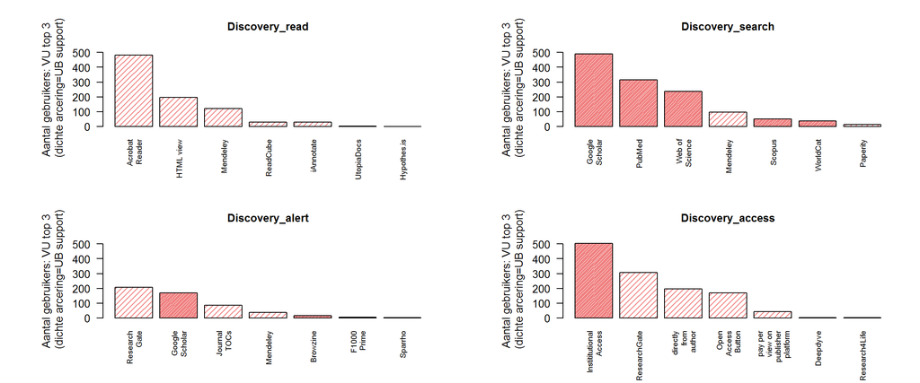

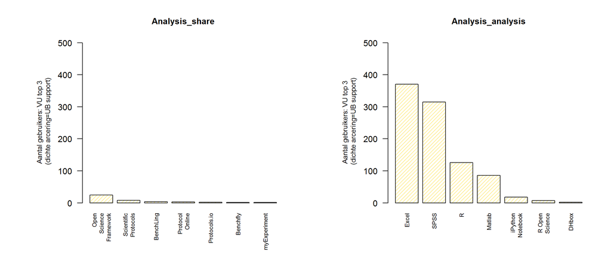

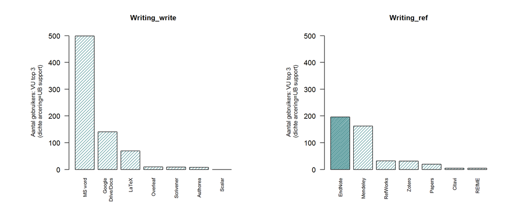

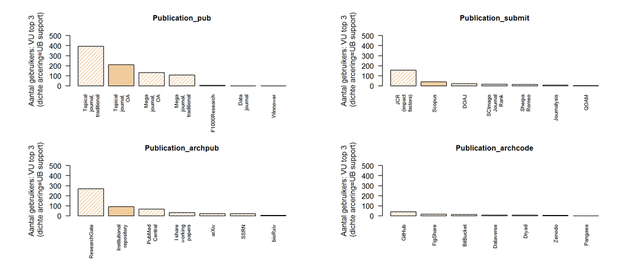

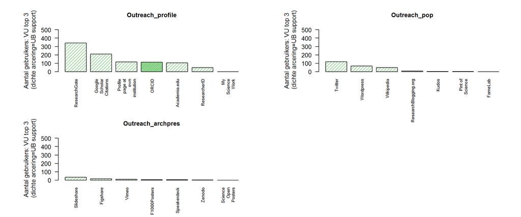

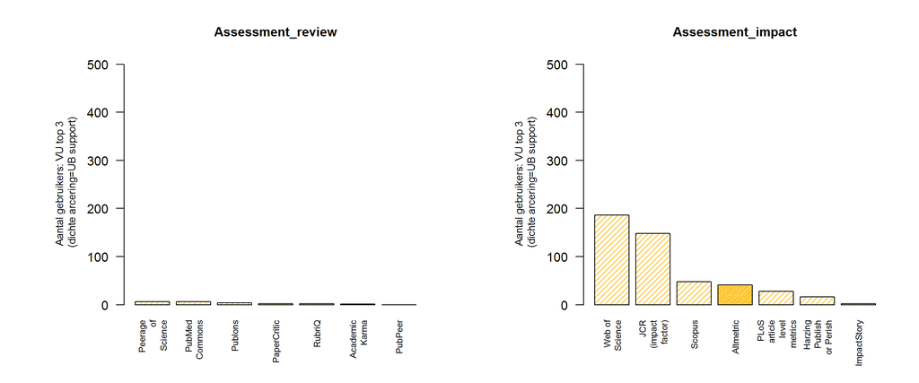

# VU&VUmc vs OECD countries

# VU&VUmc vs OECD countries

Despite the fact that the survey has responses from many different countries, we limit the analysis to the 34 [OECD member states](http://www.oecd.org/about/membersandpartners/list-oecd-member-countries.htm) (checked 3 May 2016), as these countries are more similar to the Netherlands, and comparison is more meaningful. For example, respondents from countries with low GDP often use Zotero (free of charge), while EndNote (paid) is used more in countries with a higher GDP.

Overall, differences between OECD and VU repondents are not very large, but there are a few tools that stand out.

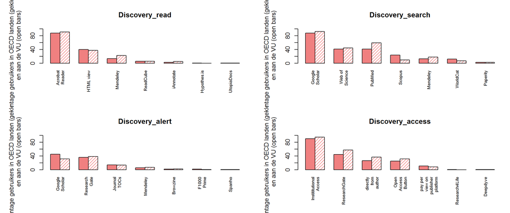

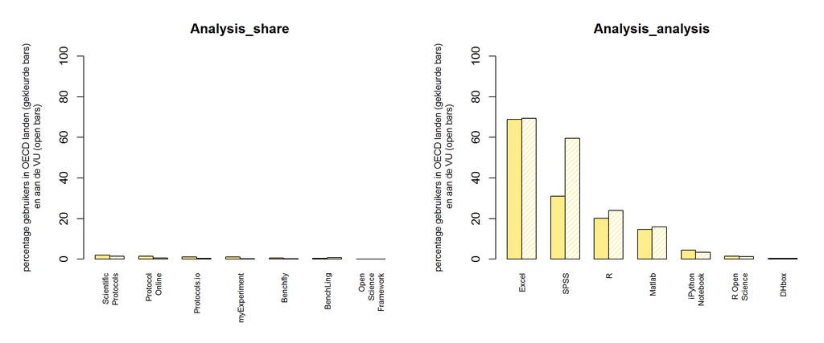

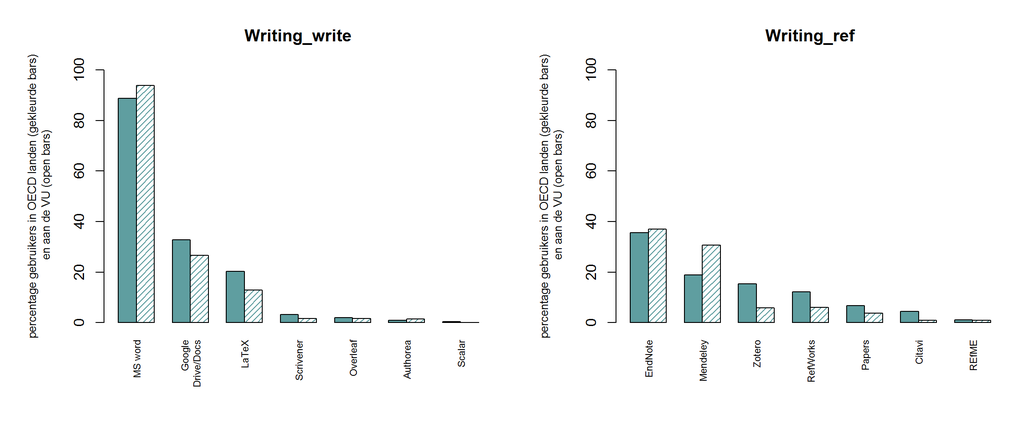

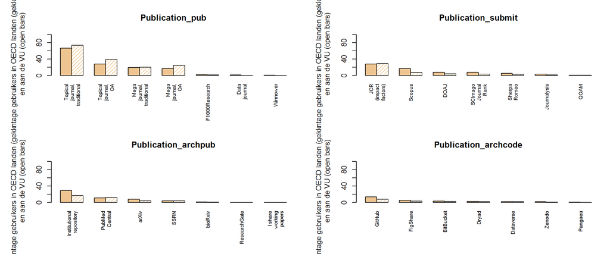

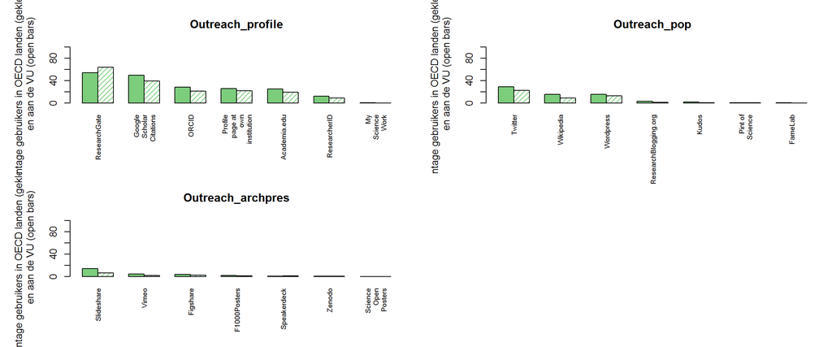

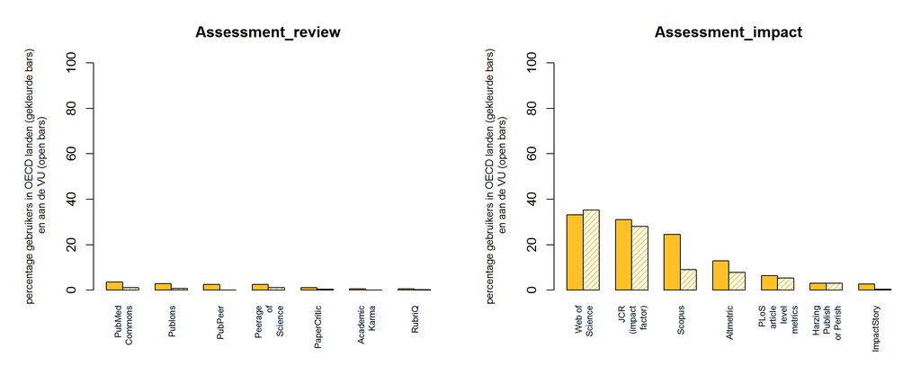

# Career groups and Tool usage

At this stage we would like to see if there are tools used that differ between the academic careergroups at the VU and VUmc. In the data we labeled the PhDs and post docs as non-tenured and the other (assistant) professors were labeled as tenured researchers.

## Extremities: Tenures vs Non-tenures

The figure below shows only the tools with the biggest difference between tenures users and non-tenured researchers.

Please note that the bars of the Tenured group is filled with the color of the research phase. The bars of the Non-tenured group are shaded.

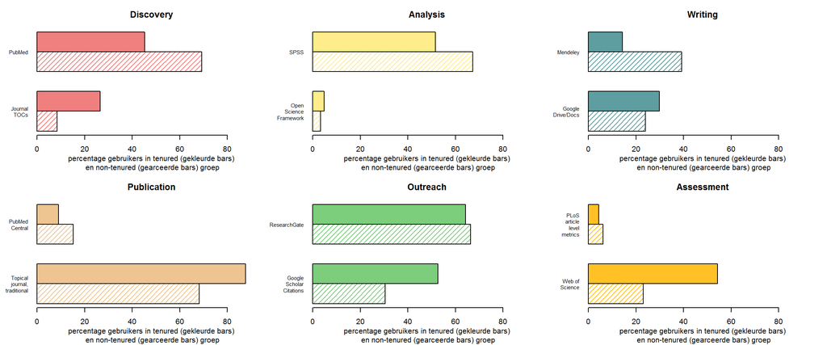

## Details: Tenures vs Non-tenures grouped by research activities

Here we see all tools in the survey sorted by research phase and research activity.

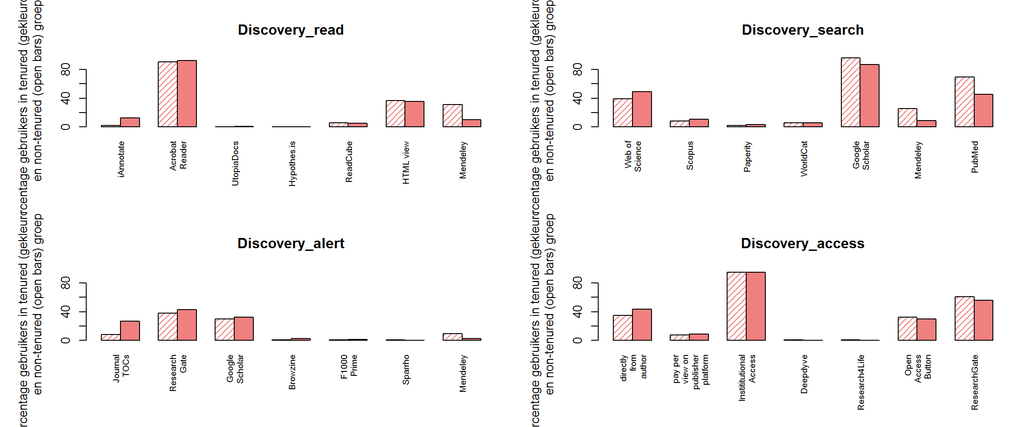

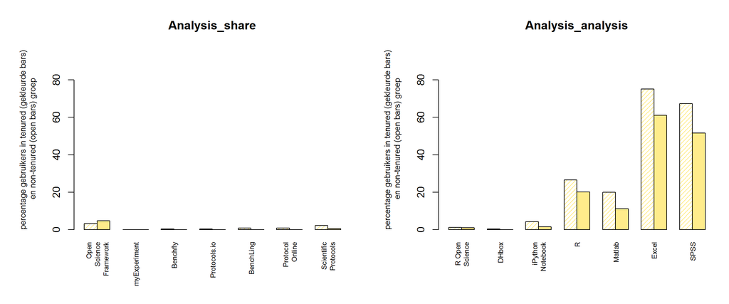

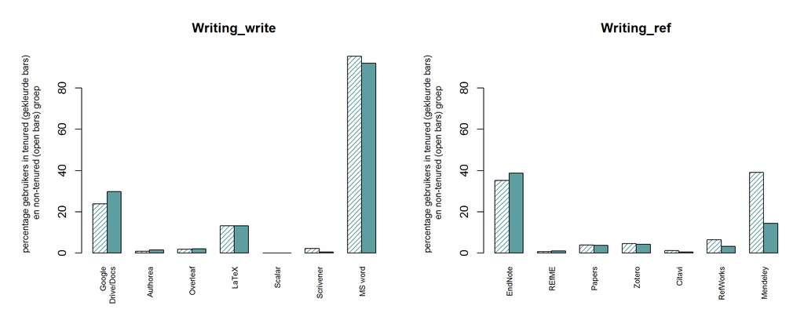

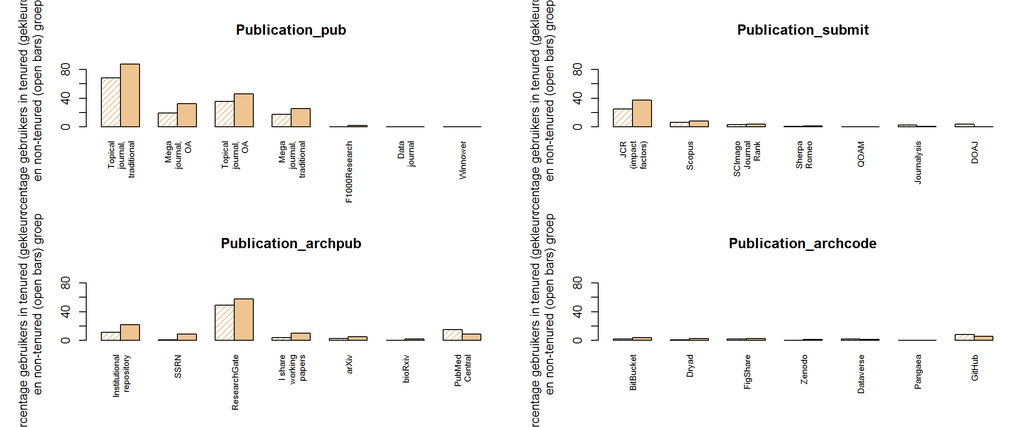

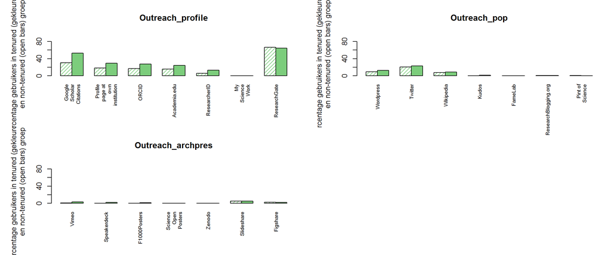

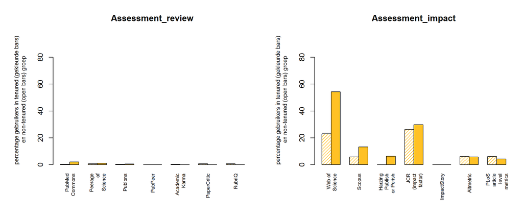

# Open Access and Open Science

## Tenures vs Non-tenures

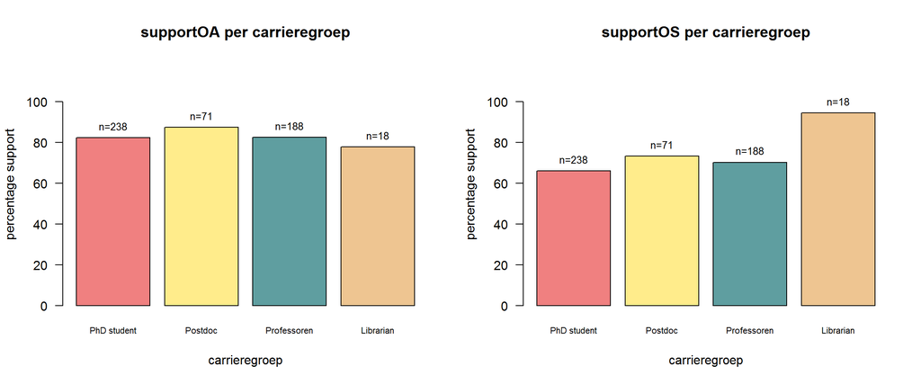

## Per Discipline: Open Access and Open Science

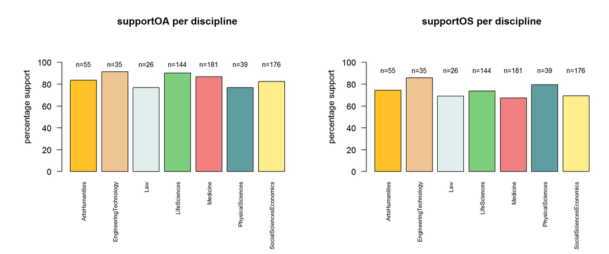

# Tools per discipline

## Most used tool per Research Phase

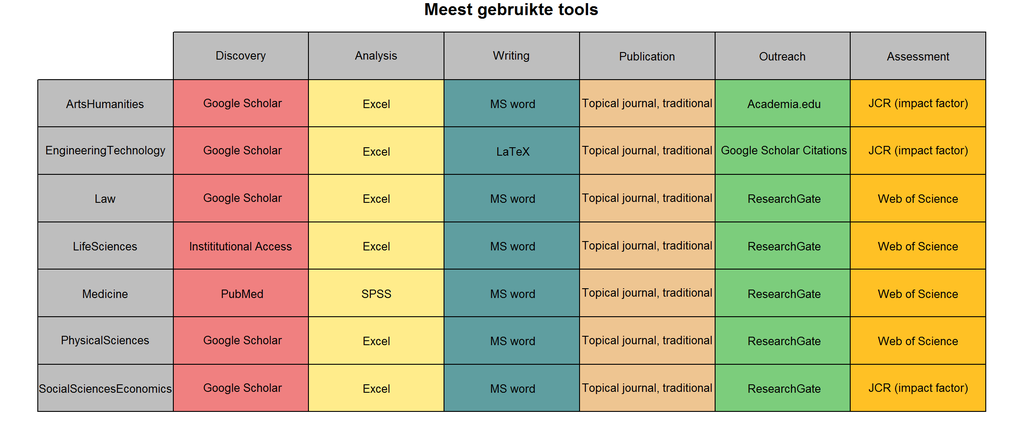

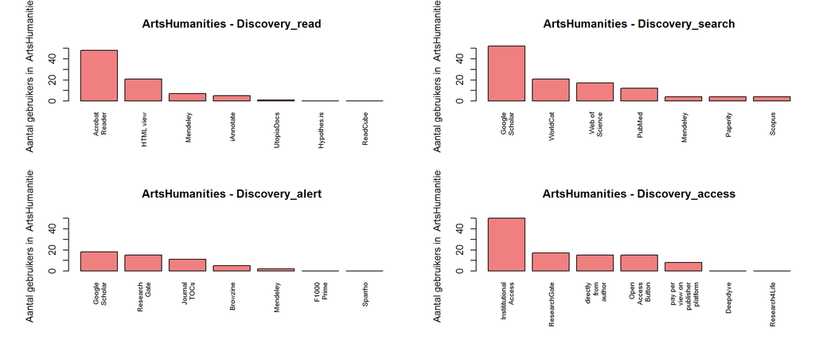

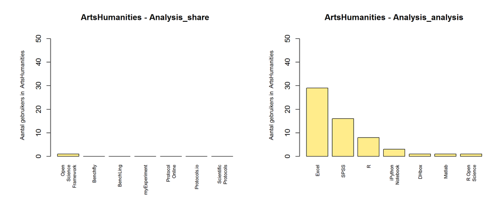

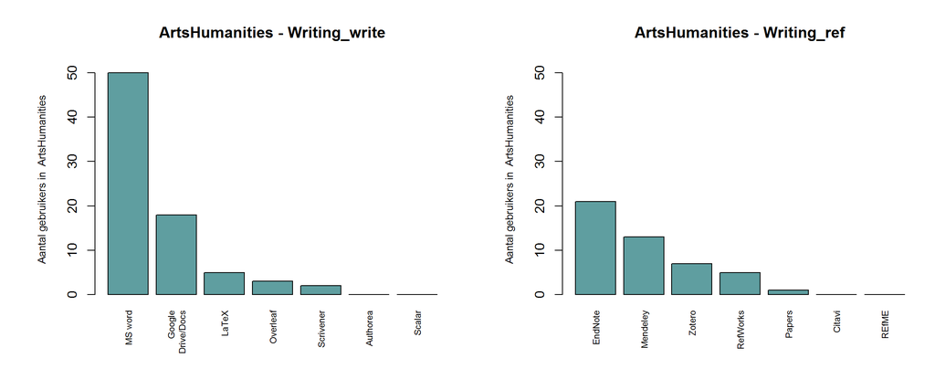

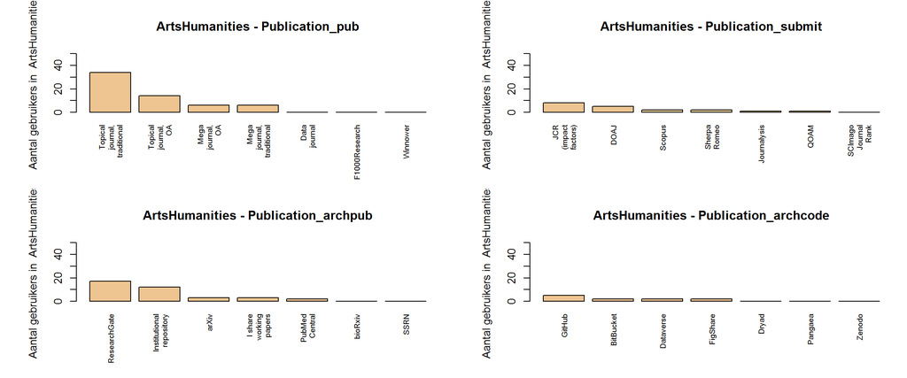

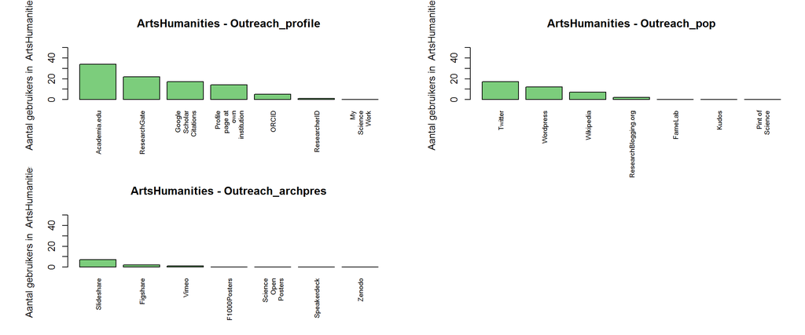